# Lichen biomass

[NO_LAVH_001]

Author

Affiliation

Anders Kolstad

The Norwegian Institute for Nature Research (NINA)

Published

July 3, 2026

Reviewed by

Matthew Grainger

> **Recommended citation**: Kolstad, A. 2026. Lichen biomass [Reinlav] (ID: NO_LAVH_001) v. 1.0.1. ecRxiv: https://github.com/NINAnor/ecRxiv/tree/main/indicators/NO_LAVH_001

**Metadata**

Table 1: Indicator metadata

| Variable | Value |
| --- | --- |
| Indicator ID | NO_LAVH_001 |
| Indicator Name | Lichen biomass [Reinlav] |
| verbatimName | Reinlav i villreinkommuner |
| Country | Norway |
| Continent | Europe |
| Ecosystem Condition Typology Class | B2 - Structural state characteristics |
| Realm | Terrestrial (T) |
| Biome | T6 Polar-alpine (cryogenic) biome |
| Ecosystem | NA |
| verbatimEcosystem | Fjell |
| Year added | 2026 |
| Last update | 2026 |
| Version | 1.0.1 |
| Version comment | Change verbatim name |
| Normalised | TRUE |
| Spatial aggregation pathway | [Scale - truncate] - aggregate (regions) - aggregate (national) |
| Precision | The indicator is preseneted with uncertainties representing the probability of the true value of the indicator |

**Log**

- May 28, 2026 - Started work
- July 3, 2026 - Accepted
- August 12 2026 - Minor update to metadata
- September 30 2026 - Change verbatim name

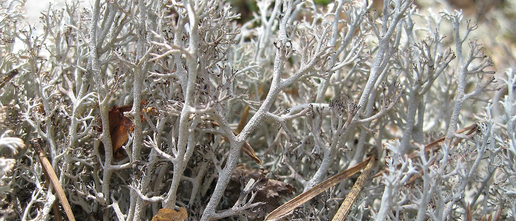

Figure 1: Reindeer lichen. Photo: Public domain, CC0, via Wikimedia Commons.

```r
knitr::include_graphics(here::here("img/1280px-Cladonia_rangiferina_Grå_reinlav.png"))
```

## 1. Summary

1. **Background and rationale**: Lichens, and lichen heaths, are common and important features of alpine ecosystems. They are important food sources for reindeer, hence the common Norwegian term ‘reindeer lichens’. This group of lichens are characteristically white in colour. This makes them important in climate forcing by increasing the surface albedo (reflectivness) . It also makes them easily recognisable via remote sensing. The cover and biomass of lichen is affected by several anthopogenic drivers, including climate change and land use change. Climate warming and reduced livestock grazing causes shrubification (an increase in the abundance and density of shrub species) and forest advance, whereas lichen cover can also become reduced because of reindeer overgrazing.
2. **Methods**: Lichen biomass is estimated by using a machine learning model on landsat satellite imagery, every year from 19884 to 2024, for wild reindeer areas. Areas dominated by semi-domesticated raindeer are not included. The variable is defined as the proportion of area with lichen heath in good condition, following the ‘Kvalitetsnorm for villrein’.  
   We get the data from the Norwegian Nature Index database (Nater and Eriksen 2025) where also the X<sub>100</sub> reference values are stored.
3. **Interpretation**: An indicator value of 1 means that the area with lichen heath in good condition (i.e. with sufficient lichen biomass) is equal to or greater than that estimated under the reference condition. An indicator value decreasing towards zero indicates a reduction in condition relative to the reference and an indicator value of zero indicating all areas are in poor condition.
4. **Results and development needs**: The indicator value for Norway as a whole in 2024 was 0.73 [95% CI = 0.72-0.74], something which can be interpreted as *good condition*. The national indicator values are showing a weak decline since 2010. The indicator has highest values in southern Norway (0.89) and lowest values in west (0.66). Development needs include to calculate this same indicator for all areas, including municipalities dominated by semi-natural reindeer.

## 1.2 Native language summary - Norwegian

1. **Bakgrunn og begrunnelse**: Reinslav er en gruppe busklav som i fjellet danner lavheier. Disse er vanlige og viktige elementer i alpine økosystemer hvor de blant annet en viktig matkilde for rein. Denne gruppen lav er karakteristisk hvit i fargen. Dette gjør dem viktige for klimaregulering ved å øke overflatens albedo. Den lyse fargen gjør dem også lett gjenkjennelige ved hjelp av fjernmåling. Dekning og biomasse av lav påvirkes av flere menneskeskapte drivere, inkludert klimaendringer og arealbruksendringer. Klimaoppvarming og redusert beitetrykk fra husdyr kan føre til gjengroing med busker og trær, mens lavdekket også kan reduseres som følge av overbeiting fra rein.
2. **Metoder**: Lavbiomasse estimeres ved hjelp av en kunstig intelligens matet med Landsat-satellittbilder. Dette har blitt gjort for alle årene fra 1984 til 2024, innenfor kommuner med villrein. Områder dominert av tamrein er ikke inkludert. Variabelen er definert som andelen areal med lavhei i god tilstand, i henhold til Kvalitetsnorm for villrein. Dataene hentes fra databasen for Naturindeks for Norge (Nater and Eriksen 2025), hvor også referanseverdiene X<sub>100</sub> er lagret.
3. **Tolkning**: En indikatorverdi på 1 betyr at andelen areal med lavhei i god tilstand (det vil si med tilstrekkelig lavbiomasse) er lik eller større enn det som er estimert under referansetilstanden. En indikatorverdi som nærmer seg null indikerer en reduksjon i denne andelen, inntil en verdi på 0, som betyr at alle arealer er i dårlig tilstand eller at lavhene er borte.
4. **Resultater og utviklingsbehov**: Indikatorverdien for hele Norge i 2024 er 0,73 [95 % KI = 0,72–0,74], noe som kan tolkes som god tilstand. De nasjonale indikatorverdiene viser en svak nedgang siden 2010. Indikatoren har høyest verdi i Sør-Norge (0,89) og lavest verdi i Vest-Norge (0,66). Utviklingsbehov inkluderer å beregne den samme indikatoren for alle områder, også kommuner og regioner dominert av tamrein.

## 2. About the underlying data

The data comes from an analyses of landsat imagery, which has been analysed using artificial intelligence (AI) as explained in (Erlandsson et al. 2024). I will extract variable values and reference values from the Norwegian Nature Index (Nater and Eriksen 2025) database.

### 2.2 Sampling design

The sampling is complete (wall-to-wall) within the area of selected *wild reindeer municipalities*.

### 2.3 Original units

The units from the variable as it is exported from the Naturindeks *is the proportion of [total] area with lichen heath in good condition, following the ‘Kvalitetsnorm for villrein’*. Before this threshold definition, the variable is defined as biomass per unit area.

I added *total* to the quote from Naturindeks above to clarify that the variables takes into account all the (assuming alpine) terrestrial area in the municipality, so that is a municipality has 30% lichen heath cover, then X<sub>100</sub>equals 30%, not 100%.

### 2.4 Instructions for citing, using and accessing data

Indicator values from the Norwegian Nature Index can be found in (Nater et al. 2025). Indicator values, variable values and reference values can be downloaded from the Nature Index database using the API, as I have done below. The data is licenced under [CC-BY 4.0](https://creativecommons.org/licenses/by/4.0/).

## 3. Indicator properties

### 3.1 Ecosystem Condition Typology Class (ECT)

B2 - Structural state characteristics

### 3.2 Ecosystem condition characteristic

The ecosystem characteristic represented in this indicator is an ecosystem where the vegetation, in terms of cover, composition and biomass, is close to that we expect under the reference condition.

### 3.3 Collinearities with other indicators

None that are very obvious. The indicator could be correlated to indicators on reindeer grazing pressure.

### 3.4 Impact factors

The biomass and cover of lichen heaths is reduced by overgrazing and shrub/forest enchroachment due to changes in land use and land use intensity.

### 3.5 Spatial aggregation

The data is imported at a scale of municipalities. It is then normalised before aggregated to gorgraphical regions, and then to Norway.

## 4. Reference condition and levels

### 4.1 Reference condition

The reference condition is a mountain ecosystem with minimal human impact and a climate similar to the period 1961-1990 (Nybø and Evju (red) 2017).

### 4.2 Reference levels

X<sub>100</sub> is defined as all the lichen heath area in a municiaplity is in in good condition, as defined by the ‘Kvalitetsnorm for villrein’ (Figure 2).

X<sub>0</sub> is defined as a complete absence of lichens.

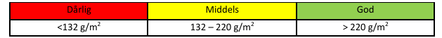

Figure 2: Threshold values for how much lichen biomass an area must have to be classed as good (god), intermediate (middels) or bad (dårlig). Taken from the Kvalitetsnorm for villrein.

```r
knitr::include_graphics(here::here("img/trafikklys.png"))
```

#### 4.2.1 Spatial resolution and validity

The reference values vary between municipalities in Norway.

## 5. Uncertainties

### 5.1 General uncertainties

The main source of uncertainty arises from the spatial bias, i.e that municipalities dominated by semi-domestic reindeer are excluded.

### 5.2 Reported uncertainties

The reported uncertainties reflect the uncertainties around the true parameter means, i.e. they are inferrential uncertainties for the true value of the indicator for the given area and time combination.

## 6. References

Erlandsson, R., K. Ostapowicz, K. Langeland, T. Tveraa, E. Aasmo Finne, and H. Tømmervik. 2024. *[Kartlegging av lavbeitenes biomasse tilbake i tid](http://hdl.handle.net/11250/3121824)*. NINA Rapport 2426. Norsk institutt for naturforskning (NINA).

Nater, C. R., and L. F. Eriksen. 2025. *Naturindeks for Norge 2025. Tilstand og utvikling for biologisk mangfold.* {NINA} {Temahefte} 97. Trondheim: Norsk Institutt for Naturforskning.

Nater, C. R., T. Zeiner-Henriksen, and S. Nybø. 2025. NI2025: Indicator Data. doi:10.21345/y790-v762.

Nybø, S., and M. Evju (red). 2017. *[Fagsystem for fastsetting av god økologisk tilstand - forslag fra et ekspertråd](https://www.regjeringen.no/no/dokumenter/fagsystem-for-fastsetting-av-god-okologisk-tilstand/id2558481/)*.

## 7. Import and prepare datasets

### 7.1 Naturindeks

We download the dataset from the Naturindeks database using the API. The function gives read-only access without requiring a username and password.

```r
# I use a dev version of NIcalc where the username and passwork for the guest user is hrd coded into the function. This will probably be merged into the real NIcalc (from NINAnor/NIcalc) soon.
# renv::install("ChloeRN/NIcalc@include_ReadOnly_access")
# library(NIcalc)

#myYears <- as.character(c(1990, 2020, 2010, 2014, 2019, 2024))

# Import data set
lavhImport <- NIcalc::importDatasetApi(
  eco = NULL,
  indic = c("Lavhei i villreinkommuner"),
  year = c("2010", "2014", "2019", "2024")
)
saveRDS(lavhImport, here::here("data/lavhImport.rds"))
```

## 8. Spatial units

According to the Naturindeks terminology, the 430 municipalities are called `BSunits`. In the current dataset, only 83 ‘wild reindeer’ municipalities’ are included. The remaining municipalities dont have any data. The `BSunits` are also called `ICunits` in the case of this indicator.

## 9. Analyses

Here I use a generic approach to handling data from the Naturindeks where I get both the variable values and the reference values, separately, from the NI database, and perform the normalisation and spatial aggregation ourselves.

The reference values have uncertainties attached to them, which we will ignore here. The variable values have uncertainties as well, in the form of probability function. The uncertainties are from a statistical model, and so we think of them as inferential uncertainties.

Here I use an NIcalc function to just prepare and structure the data a little differently.

```r
# Assemble
assemble <- NIcalc::assembleNiObject(
  inputData = lavhImport,
  predefNIunits = c(allArea = T, parts = T, counties = F),
  indexType = "thematic"
)
```

Then I get the reference values. These are unique to each ´ICunit` (municipality). I only have an X<sub>100</sub> value. X<sub>0</sub> is a natural zero.

```r
x100 <- lavhImport$referenceValues$referenceValues |>
  select(ICunitId, ICunitName, x100 = expectedValue)
head(x100)
```

```
# A tibble: 6 × 3
  ICunitId ICunitName  x100
     <int> <chr>      <dbl>
1    16309 Alvdal      91.5
2    16310 Askvoll     66.4
3    16311 Aurland     87.1
4    16312 Bygland     55.6
5    16313 Bykle       55.6
6    16314 Dovre       79.7
```

The variable values are stored as a parameterised probability function, and I need to draw *n* samples from this function. The probability function differs between indicators in the Naturindeks. It could also differ within an indicator. Here I create a vector defining which probability function to use. I use ´tradObs´ where there is a regular probability distribution family, and `customObs` where customDist!= NA. When `distributionFamilyName == NA`, `customDistribution != NA`.

```r
myYears <- as.character(c(2010, 2014, 2019, 2024))

obstype <- NULL

for (i in 1:length(myYears)) {
  obs <- assemble$indicatorValues[[i]]$distributionFamilyName

  obs[!is.na(obs)] <- "tradObs"
  obs[is.na(obs)] <- "customObs"

  obstype[[i]] <- obs
}
```

Now I am ready to sample the probability distributions. I set *n* to be 1000.

```r
dat <- tibble(ICunitId = NULL, value = NULL, year = NULL)

for (i in 1:length(myYears)) {
  #print(i)
  myMat <- NIcalc::sampleObsMat(
    ICunitId = assemble$indicatorValues[[i]]$ICunitId,
    value = assemble$indicatorValues[[i]]$expectedValue,
    distrib = assemble$indicatorValues[[i]]$distributionFamilyName,
    mu = assemble$indicatorValues[[i]]$distParameter1,
    sig = assemble$indicatorValues[[i]]$distParameter2,
    customDistribution = assemble$indicatorValues[[i]]$customDistribution,
    obsType = obstype[[i]],
    nsim = 1000
  )
  ICunitIds <- row.names(myMat)

  myMat <-  myMat |>
    as_tibble() |>
    add_column(ICunitId = ICunitIds, .before = 1) |>
    pivot_longer(cols = -any_of("ICunitId")) |>
    select(-name) |>
    add_column(year = myYears[i])

  dat <- dat |>
    bind_rows(myMat)
}
head(dat)
```

```
# A tibble: 6 × 3
  ICunitId value year
  <chr>    <dbl> <chr>
1 16309     70.5 2010
2 16309     78.5 2010
3 16309     72.5 2010
4 16309     75.0 2010
5 16309     78.6 2010
6 16309     73.9 2010
```

This is the point in the spatial aggregation where we should normalise against the reference values. So let’s add inn the X<sub>100</sub> values.

```r
dat <- dat |>
  left_join(x100 |> mutate(ICunitId = as.character(ICunitId)), by = join_by(ICunitId))
```

### Normalise

Then we can normalise also the scatter plot with variables against indicator values (Figure 3).

```r
ind <- ec_normalise(
  variable = dat$value,
  x100 = dat$x100
)

dat <- dat |> add_column(indicator = ind)
```

```r
myMax <- max(dat$x100)
temp <- ec_norm_plot(dat$value, dat$indicator) +
  labs(x = "% of total area\nwhich is lichen heath in good condition") +
  xlim(c(0,myMax))

ggsave(here::here("img/norm_plot_eng_lavh.png"), scale =1.5, plot =temp)
```

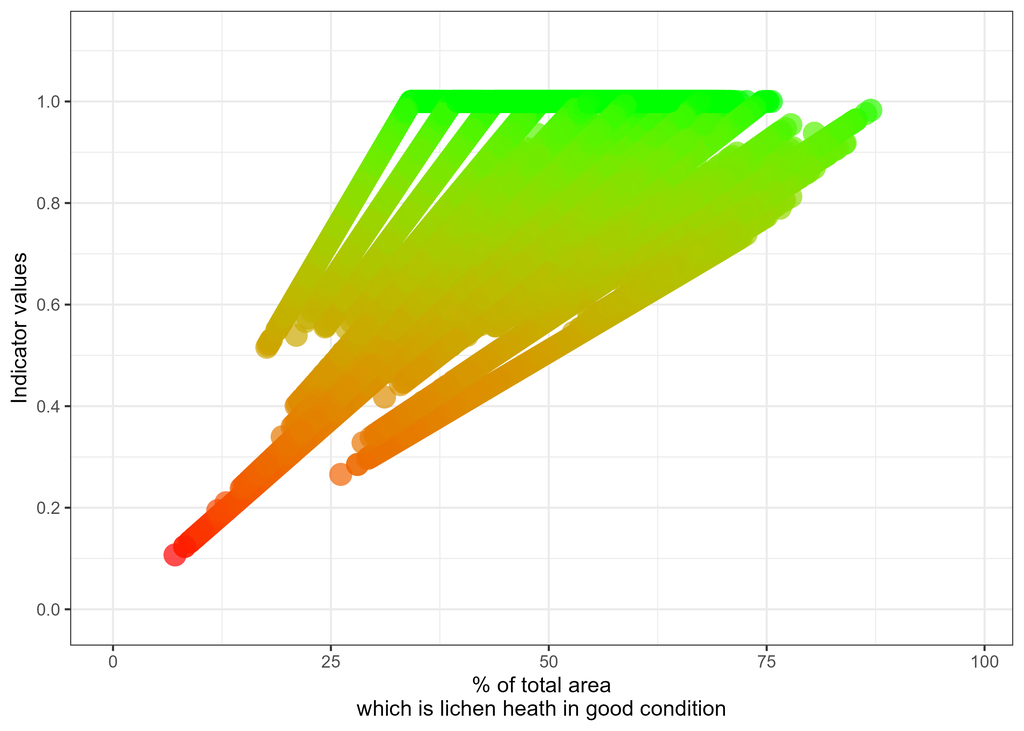

Figure 3: Normalisation (scaling and truncation) of variable values into indicator values. The X100 value differs municipalities in Norway hence the many overlapping lines.

```r
knitr::include_graphics(here::here("img/norm_plot_eng_lavh.png"))
```

I also export a figure for the Norwegian fact sheet:

**Export normalisation function plots**

```r
temp <- ec_norm_plot(dat$value, dat$indicator, lan = "norsk") +
  labs(x = "% av totalt areal\nsom er lavhei i god tilstand", y = "Indikatorverdi") +
  xlim(c(0, myMax))
ggsave(here::here("img/norm_plot_lavh.png"), scale =1.5, plot =temp)
```

```r
# The link between BSunits and NIunits can be found here:
bs_ni <- as.data.frame(assemble$NIunits) |>
  rownames_to_column(var = "BSunits")
head(bs_ni)
```

```
      BSunits wholeArea E S W C
1       Hamar         1 1 0 0 0
2   Ringsaker         1 1 0 0 0
3        Åmot         1 1 0 0 0
4 Stor-Elvdal         1 1 0 0 0
5    Rendalen         1 1 0 0 0
6       Tolga         1 1 0 0 0
```

```r
# and we also get the alpine area
bs_fjell <- as.data.frame(assemble$BSunits) |>
  select(BSunits = name, Fjell) |>
  mutate(BSunits = as.character(BSunits))
head(bs_fjell)
```

```
       BSunits     Fjell
43       Hamar  13.57110
44   Ringsaker  42.62685
55        Åmot  32.34474
56 Stor-Elvdal 385.84455
57    Rendalen 800.18657
59       Tolga 461.50125
```

```r
# and we join these
bs_ni_fjell <- bs_ni |>
  left_join(bs_fjell, by = join_by(BSunits), unmatched = "error")
head(bs_ni_fjell)
```

```
      BSunits wholeArea E S W C     Fjell
1       Hamar         1 1 0 0 0  13.57110
2   Ringsaker         1 1 0 0 0  42.62685
3        Åmot         1 1 0 0 0  32.34474
4 Stor-Elvdal         1 1 0 0 0 385.84455
5    Rendalen         1 1 0 0 0 800.18657
6       Tolga         1 1 0 0 0 461.50125
```

```r
# The BS units and ICunits are the same municipalities, but they have different codes, so I need to add CIunits as well

bs_ic <- as.data.frame(assemble$ICunits) |>
  rownames_to_column(var = "BSunits") |>
  rename(ICunitId = "Lavhei i villreinkommuner") |>
  mutate(ICunitId = as.character(ICunitId))
head(bs_ic)
```

```
      BSunits ICunitId
1       Hamar    16325
2   Ringsaker    16354
3        Åmot    16385
4 Stor-Elvdal    16365
5    Rendalen    16351
6       Tolga    16373
```

```r
# and then I combine them
bs_ni_fjell_ic <- bs_ni_fjell |>
  left_join(bs_ic, by = join_by(BSunits))
head(bs_ni_fjell_ic)
```

```
      BSunits wholeArea E S W C     Fjell ICunitId
1       Hamar         1 1 0 0 0  13.57110    16325
2   Ringsaker         1 1 0 0 0  42.62685    16354
3        Åmot         1 1 0 0 0  32.34474    16385
4 Stor-Elvdal         1 1 0 0 0 385.84455    16365
5    Rendalen         1 1 0 0 0 800.18657    16351
6       Tolga         1 1 0 0 0 461.50125    16373
```

```r
# and add the new columns to the main dataset
head(dat)
```

```
# A tibble: 6 × 6
  ICunitId value year  ICunitName  x100 indicator
  <chr>    <dbl> <chr> <chr>      <dbl>     <dbl>
1 16309     70.5 2010  Alvdal      91.5     0.770
2 16309     78.5 2010  Alvdal      91.5     0.858
3 16309     72.5 2010  Alvdal      91.5     0.793
4 16309     75.0 2010  Alvdal      91.5     0.820
5 16309     78.6 2010  Alvdal      91.5     0.859
6 16309     73.9 2010  Alvdal      91.5     0.808
```

```r
dat_expand <- dat |>
  right_join(
    bs_ni_fjell_ic,
    by = join_by(ICunitId),
    unmatched = "error",
    relationship = "many-to-many"
  )
head(dat_expand)
```

```
# A tibble: 6 × 13
  ICunitId value year  ICunitName  x100 indicator BSunits wholeArea     E     S
  <chr>    <dbl> <chr> <chr>      <dbl>     <dbl> <chr>       <dbl> <dbl> <dbl>
1 16309     70.5 2010  Alvdal      91.5     0.770 Alvdal          1     1     0
2 16309     78.5 2010  Alvdal      91.5     0.858 Alvdal          1     1     0
3 16309     72.5 2010  Alvdal      91.5     0.793 Alvdal          1     1     0
4 16309     75.0 2010  Alvdal      91.5     0.820 Alvdal          1     1     0
5 16309     78.6 2010  Alvdal      91.5     0.859 Alvdal          1     1     0
6 16309     73.9 2010  Alvdal      91.5     0.808 Alvdal          1     1     0
# ℹ 3 more variables: W <dbl>, C <dbl>, Fjell <dbl>
```

```r
# and we create a column for the regions
dat_expand2 <- dat_expand |>
  select(-wholeArea) |>
  mutate(across(c(E, S, W, C), ~ na_if(., 0))) |>
  pivot_longer(cols = c(E, S, W, C), values_drop_na = T, values_to = "count", names_to = "part") |>
  select(-count)
head(dat_expand2)
```

```
# A tibble: 6 × 9
  ICunitId value year  ICunitName  x100 indicator BSunits Fjell part
  <chr>    <dbl> <chr> <chr>      <dbl>     <dbl> <chr>   <dbl> <chr>
1 16309     70.5 2010  Alvdal      91.5     0.770 Alvdal   318. E
2 16309     78.5 2010  Alvdal      91.5     0.858 Alvdal   318. E
3 16309     72.5 2010  Alvdal      91.5     0.793 Alvdal   318. E
4 16309     75.0 2010  Alvdal      91.5     0.820 Alvdal   318. E
5 16309     78.6 2010  Alvdal      91.5     0.859 Alvdal   318. E
6 16309     73.9 2010  Alvdal      91.5     0.808 Alvdal   318. E
```

### Spatial aggregation

Then we can aggregate (upscale) from municipalities to geographic regions using `ecTools`. This uses a Monte Carlo propagation of the uncertainties.

This takes a while to run with n = 1000.

```r
mc_propagated <- ecTools::ec_upscale(
  data = dat_expand2,
  variable = indicator,
  weight = Fjell,
  start_units = BSunits,
  end_units = part,
  year = year,
  end_units_name = "part",
  n = 1000
)
saveRDS(mc_propagated, here::here("data/mc_propagated.rds"))
```

To get the national indicator estimate, we will do another MC propagation from geographic regions to national scale. So we need the summed mountain area per geographic region. I only sum from the included municipalities.

```r
aux <- dat_expand2 |>
  select(-indicator) |>
  distinct(BSunits, .keep_all = T) |>
  group_by(part) |>
  summarise(alpine_area = sum(Fjell))
aux
```

```
# A tibble: 4 × 2
  part  alpine_area
  <chr>       <dbl>
1 C           6563.
2 E          15178.
3 S           6513.
4 W          13019.
```

```r
mc_propagated <- mc_propagated |>
  left_join(aux, by = join_by(part)) |>
  add_column(end_units = "Norway")

mc_propagated2 <- ecTools::ec_upscale(
  data = mc_propagated,
  variable = sampled_mean,
  weight = alpine_area,
  start_units = part,
  end_units = end_units,
  year = year,
  end_units_name = "part",
  n = 1000
)
saveRDS(mc_propagated2, here::here("data/mc_propagated2.rds"))
```

Then we append this to the main dataset

```r
mc_propagated3 <- mc_propagated |>
  select(year, part, sampled_mean) |>
  bind_rows(mc_propagated2)
```

## 10. Results

Then we create some summary statistics (Table 2) and plot them (Figure 4).

```r
summary_out <- mc_propagated3 |>
  group_by(part, year) |>
  summarise(
    median = round(median(sampled_mean), 2),
    p_025 = round(quantile(sampled_mean, probs = 0.025), 2),
    p_25 = round(quantile(sampled_mean, probs = 0.25), 2),
    p_75 = round(quantile(sampled_mean, probs = 0.75), 2),
    p_975 = round(quantile(sampled_mean, probs = 0.975), 2),
  ) |>
  add_column(
    ECT = "B2",
    Indicator = "Lichen biomass",
    Ecosystem = "Mountains",
    ID = "NO_LAVH_001"
  )
```

```r
part_labels <- c(
  N = "North",
  C = "Central",
  W = "West",
  S = "South",
  E = "East",
  Norway = "Norway",
  All = "Norway"
)

region_levels <- c("Norway", "Central", "East", "North", "South", "West")

region_cols <- setNames(
  MetBrewer::met.brewer("Archambault", n = length(region_levels)),
  region_levels
)

plot_data <- summary_out |>
  mutate(
    year = factor(year, levels = myYears),
    series_type = if_else(part == "Norway", "National", "Region"),
    part2 = recode(part, !!!part_labels)
  )
```

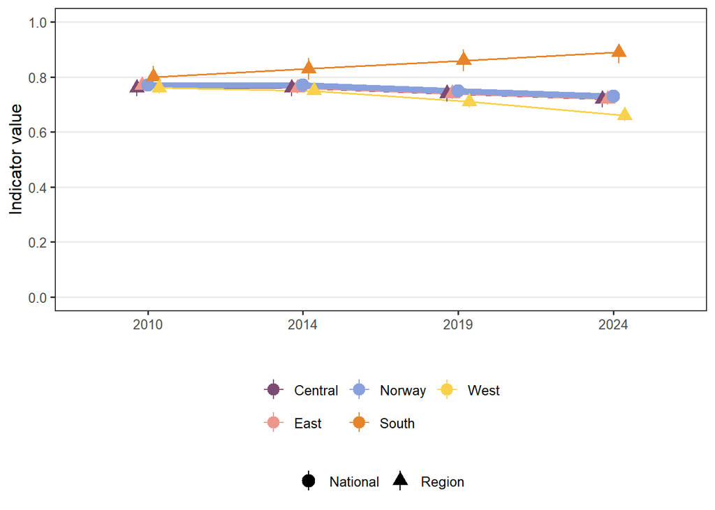

Figure 4: Indicator values for NO_LAVH_001 (Lichen biomass) plotted over time and for four different regions (there is no data from Northern Norway), as well as the combined national estimated. The error bars are 95% confidence intervals.

```r
ggplot(plot_data, aes(x = year, y = median, colour = part2, group = part2)) +
  geom_line(
    aes(linewidth = series_type),
    position = position_dodge(width = 0.18)
  ) +
  scale_linewidth_manual(
    values = c(National = 2, Region = 0.55),
    guide = "none"
  ) +
  geom_pointrange(
    aes(ymin = p_025, ymax = p_975, shape = series_type),
    size = 0.8,
    linewidth = 0.45,
    position = position_dodge(width = 0.18)
  ) +
  scale_colour_manual(values = region_cols, name = NULL) +
  scale_shape_manual(
    values = c(National = 19, Region = 17),
    name = NULL
  ) +
  scale_y_continuous(limits = c(0, 1), breaks = seq(0, 1, 0.2)) +
  theme_bw(base_size = 12) +
  theme(
    legend.position = "bottom",
    legend.box = "vertical",
    panel.grid.minor = element_blank(),
    panel.grid.major.x = element_blank()
  ) +
  guides(
    colour = guide_legend(
      nrow = 2,
      override.aes = list(size = 0.7, linewidth = 0.45)
    ),
    shape = guide_legend(override.aes = list(size = 0.8, linewidth = 0.45))
  ) +
  labs(y = "Indicator value", x = "")
```

```r
summary_out |>
  unite(col = "CI_95", c(p_025, p_975), sep = " - ") |>
  unite(col = "IQR", c(p_25, p_75), sep = " - ") |>
  select(
    ECT,
    Indicator,
    ID,
    "Accounting area" = part,
    Ecosystem,
    "Closing year" = year,
    "Indicator value" = median,
    "95% CI" = CI_95,
    "50% CI" = IQR
  ) |>
  knitr::kable()
```

Table 2: Indicator values and uncertainty estimates for NO_LAVH_001.

| ECT | Indicator | ID | Accounting area | Ecosystem | Closing year | Indicator value | 95% CI | 50% CI |
| --- | --- | --- | --- | --- | --- | --- | --- | --- |
| B2 | Lichen biomass | NO_LAVH_001 | C | Mountains | 2010 | 0.76 | 0.73 - 0.78 | 0.75 - 0.76 |
| B2 | Lichen biomass | NO_LAVH_001 | C | Mountains | 2014 | 0.76 | 0.73 - 0.78 | 0.75 - 0.76 |
| B2 | Lichen biomass | NO_LAVH_001 | C | Mountains | 2019 | 0.74 | 0.71 - 0.76 | 0.73 - 0.75 |
| B2 | Lichen biomass | NO_LAVH_001 | C | Mountains | 2024 | 0.72 | 0.69 - 0.74 | 0.71 - 0.73 |
| B2 | Lichen biomass | NO_LAVH_001 | E | Mountains | 2010 | 0.77 | 0.75 - 0.79 | 0.76 - 0.78 |
| B2 | Lichen biomass | NO_LAVH_001 | E | Mountains | 2014 | 0.76 | 0.74 - 0.78 | 0.75 - 0.77 |
| B2 | Lichen biomass | NO_LAVH_001 | E | Mountains | 2019 | 0.74 | 0.72 - 0.76 | 0.73 - 0.75 |
| B2 | Lichen biomass | NO_LAVH_001 | E | Mountains | 2024 | 0.72 | 0.7 - 0.74 | 0.71 - 0.73 |
| B2 | Lichen biomass | NO_LAVH_001 | Norway | Mountains | 2010 | 0.77 | 0.76 - 0.78 | 0.77 - 0.77 |
| B2 | Lichen biomass | NO_LAVH_001 | Norway | Mountains | 2014 | 0.77 | 0.76 - 0.78 | 0.77 - 0.77 |
| B2 | Lichen biomass | NO_LAVH_001 | Norway | Mountains | 2019 | 0.75 | 0.74 - 0.76 | 0.74 - 0.75 |
| B2 | Lichen biomass | NO_LAVH_001 | Norway | Mountains | 2024 | 0.73 | 0.72 - 0.74 | 0.72 - 0.73 |
| B2 | Lichen biomass | NO_LAVH_001 | S | Mountains | 2010 | 0.80 | 0.76 - 0.84 | 0.79 - 0.81 |
| B2 | Lichen biomass | NO_LAVH_001 | S | Mountains | 2014 | 0.83 | 0.79 - 0.87 | 0.82 - 0.85 |
| B2 | Lichen biomass | NO_LAVH_001 | S | Mountains | 2019 | 0.86 | 0.82 - 0.9 | 0.85 - 0.87 |
| B2 | Lichen biomass | NO_LAVH_001 | S | Mountains | 2024 | 0.89 | 0.85 - 0.92 | 0.87 - 0.9 |
| B2 | Lichen biomass | NO_LAVH_001 | W | Mountains | 2010 | 0.76 | 0.74 - 0.78 | 0.75 - 0.77 |
| B2 | Lichen biomass | NO_LAVH_001 | W | Mountains | 2014 | 0.75 | 0.74 - 0.77 | 0.75 - 0.76 |
| B2 | Lichen biomass | NO_LAVH_001 | W | Mountains | 2019 | 0.71 | 0.69 - 0.73 | 0.7 - 0.71 |
| B2 | Lichen biomass | NO_LAVH_001 | W | Mountains | 2024 | 0.66 | 0.64 - 0.67 | 0.65 - 0.66 |

## 11. Export file

The indicator values are exported and can be found under `data/results_NO_LAVH_001_v1.0.0.csv`.

**Export data**

```r
write.csv(mc_propagated3, here::here("data/results_NO_LAVH_001_v1.0.0.csv"), row.names = F)
```

## 12. Author contributions

Not relevant, as this is the work of a single author. I would, however, like to acknowledge the work of those that created the indicator on *Naturindeks* (Nater and Eriksen 2025).

**Session Info**

This workflow uses `renv`. Run `renv::restore()` to recreate the working environment.